# Exploration

## Ford GoBike System Data Visulaization Project

## By Onyeogulu Tochukwu Rowland

## Preliminary Wrangling

> The Ford Goike Data Set includes information about individual rides made in a bike-sharing system covering the San Francisco Bay area. The data set. The data set will require some data wrangling techniques which includes merging of data stored in three(3) diferent csv file into one table before data visualization can commence.

```python
# import all packages and set plots to be embedded inline
import numpy as np
import pandas as pd
import matplotlib.pyplot as plt
import seaborn as sns

%matplotlib inline
# suppress warnings from final output
import warnings
warnings.simplefilter("ignore")
```

```python
# read in the data sets that wll be used for this project and print the head of the data
df_1 = pd.read_csv('202001-baywheels-tripdata.csv')
df_1.head()
```

|  | duration_sec | start_time | end_time | start_station_id | start_station_name | start_station_latitude | start_station_longitude | end_station_id | end_station_name | end_station_latitude | end_station_longitude | bike_id | user_type | rental_access_method |
| --- | --- | --- | --- | --- | --- | --- | --- | --- | --- | --- | --- | --- | --- | --- |
| 0 | 83118 | 2020-01-31 15:23:47.7330 | 2020-02-01 14:29:06.2630 | 400.0 | Buchanan St at North Point St | 37.804272 | -122.433537 | 400.0 | Buchanan St at North Point St | 37.804272 | -122.433537 | 13052 | Customer | NaN |
| 1 | 68239 | 2020-01-31 15:40:31.6160 | 2020-02-01 10:37:51.0000 | 99.0 | Folsom St at 15th St | 37.767037 | -122.415443 | 99.0 | Folsom St at 15th St | 37.767037 | -122.415443 | 12235 | Subscriber | NaN |
| 2 | 55407 | 2020-01-31 17:48:16.6350 | 2020-02-01 09:11:44.3170 | 197.0 | El Embarcadero at Grand Ave | 37.808848 | -122.249680 | 197.0 | El Embarcadero at Grand Ave | 37.808848 | -122.249680 | 12822 | Customer | NaN |
| 3 | 54929 | 2020-01-31 17:53:03.4130 | 2020-02-01 09:08:32.6340 | 197.0 | El Embarcadero at Grand Ave | 37.808848 | -122.249680 | 197.0 | El Embarcadero at Grand Ave | 37.808848 | -122.249680 | 11705 | Customer | NaN |
| 4 | 55700 | 2020-01-31 17:12:33.4600 | 2020-02-01 08:40:53.6460 | 12.0 | Pier 1/2 at The Embarcadero | 37.796389 | -122.394586 | 371.0 | Lombard St at Columbus Ave | 37.802746 | -122.413579 | 3673 | Customer | NaN |

```python
# read in the data sets that wll be used for this project and print the head of the data
df_2 = pd.read_csv('202002-baywheels-tripdata.csv')
df_2.head()
```

|  | duration_sec | start_time | end_time | start_station_id | start_station_name | start_station_latitude | start_station_longitude | end_station_id | end_station_name | end_station_latitude | end_station_longitude | bike_id | user_type | rental_access_method |
| --- | --- | --- | --- | --- | --- | --- | --- | --- | --- | --- | --- | --- | --- | --- |
| 0 | 62083 | 2020-02-29 18:32:30.5750 | 2020-03-01 11:47:14.0850 | 176.0 | MacArthur BART Station | 37.828410 | -122.266315 | 267.0 | Derby St at College Ave | 37.861804 | -122.253569 | 1993 | Customer | NaN |
| 1 | 1364 | 2020-02-29 23:53:53.7190 | 2020-03-01 00:16:37.9720 | 375.0 | Grove St at Masonic Ave | 37.774836 | -122.446546 | 506.0 | 7th Ave at Clement St | 37.782439 | -122.465377 | 12402 | Customer | NaN |
| 2 | 836 | 2020-02-29 23:54:03.1970 | 2020-03-01 00:07:59.8490 | 375.0 | Grove St at Masonic Ave | 37.774836 | -122.446546 | 454.0 | 7th Ave at Cabrillo St | 37.775176 | -122.465007 | 2302 | Customer | NaN |
| 3 | 1004 | 2020-02-29 23:48:34.6480 | 2020-03-01 00:05:19.2020 | 179.0 | Telegraph Ave at 27th St | 37.816073 | -122.267886 | 200.0 | 2nd Ave at E 18th St | 37.800214 | -122.253810 | 902 | Customer | NaN |
| 4 | 1007 | 2020-02-29 23:48:25.9000 | 2020-03-01 00:05:13.4490 | 179.0 | Telegraph Ave at 27th St | 37.816073 | -122.267886 | 200.0 | 2nd Ave at E 18th St | 37.800214 | -122.253810 | 11578 | Customer | NaN |

```python
# read in the data sets that wll be used for this project and print the head of the data
df_3 = pd.read_csv('202003-baywheels-tripdata.csv')
df_3.head()
```

|  | duration_sec | start_time | end_time | start_station_id | start_station_name | start_station_latitude | start_station_longitude | end_station_id | end_station_name | end_station_latitude | end_station_longitude | bike_id | user_type | rental_access_method |
| --- | --- | --- | --- | --- | --- | --- | --- | --- | --- | --- | --- | --- | --- | --- |
| 0 | 35187 | 2020-03-31 20:42:10.0790 | 2020-04-01 06:28:37.8440 | 462.0 | Cruise Terminal at Pier 27 | 37.804648 | -122.402087 | 24.0 | Spear St at Folsom St | 37.789677 | -122.390428 | 10982 | Customer | NaN |
| 1 | 14568 | 2020-03-31 22:45:25.5010 | 2020-04-01 02:48:13.7730 | 42.0 | San Francisco City Hall (Polk St at Grove St) | 37.778650 | -122.418230 | 370.0 | Jones St at Post St | 37.787327 | -122.413278 | 12617 | Customer | NaN |
| 2 | 35990 | 2020-03-31 15:08:22.3310 | 2020-04-01 01:08:12.9900 | 391.0 | 1st St at Younger Ave | 37.355030 | -121.904436 | 397.0 | Gish Rd at 1st St | 37.361867 | -121.909315 | 12812 | Customer | NaN |
| 3 | 1068 | 2020-03-31 23:55:00.4260 | 2020-04-01 00:12:49.0200 | 456.0 | Arguello Blvd at Geary Blvd | 37.781468 | -122.458806 | 107.0 | 17th St at Dolores St | 37.763015 | -122.426497 | 12955 | Customer | NaN |
| 4 | 3300 | 2020-03-31 23:00:55.6410 | 2020-03-31 23:55:56.6110 | 6.0 | The Embarcadero at Sansome St | 37.804770 | -122.403234 | 24.0 | Spear St at Folsom St | 37.789677 | -122.390428 | 13050 | Customer | NaN |

### Dataset structure

```python
# data info of the data set
df_1.info()
```

```
<class 'pandas.core.frame.DataFrame'>
RangeIndex: 295854 entries, 0 to 295853
Data columns (total 14 columns):
duration_sec               295854 non-null int64
start_time                 295854 non-null object
end_time                   295854 non-null object
start_station_id           146286 non-null float64
start_station_name         146866 non-null object
start_station_latitude     295854 non-null float64
start_station_longitude    295854 non-null float64
end_station_id             145934 non-null float64
end_station_name           146511 non-null object
end_station_latitude       295854 non-null float64
end_station_longitude      295854 non-null float64
bike_id                    295854 non-null int64
user_type                  295854 non-null object
rental_access_method       185746 non-null object
dtypes: float64(6), int64(2), object(6)
memory usage: 31.6+ MB
```

```python
# data info of the data set
df_2.info()
```

```
<class 'pandas.core.frame.DataFrame'>
RangeIndex: 432354 entries, 0 to 432353
Data columns (total 14 columns):
duration_sec               432354 non-null int64
start_time                 432354 non-null object
end_time                   432354 non-null object
start_station_id           161723 non-null float64
start_station_name         161723 non-null object
start_station_latitude     432354 non-null float64
start_station_longitude    432354 non-null float64
end_station_id             162194 non-null float64
end_station_name           162194 non-null object
end_station_latitude       432354 non-null float64
end_station_longitude      432354 non-null float64
bike_id                    432354 non-null int64
user_type                  432354 non-null object
rental_access_method       317843 non-null object
dtypes: float64(6), int64(2), object(6)
memory usage: 46.2+ MB
```

```python
# data info of the data set
df_3.info()
```

```
<class 'pandas.core.frame.DataFrame'>
RangeIndex: 176799 entries, 0 to 176798
Data columns (total 14 columns):
duration_sec               176799 non-null int64
start_time                 176799 non-null object
end_time                   176799 non-null object
start_station_id           110696 non-null float64
start_station_name         111349 non-null object
start_station_latitude     176799 non-null float64
start_station_longitude    176799 non-null float64
end_station_id             111097 non-null float64
end_station_name           111794 non-null object
end_station_latitude       176799 non-null float64
end_station_longitude      176799 non-null float64
bike_id                    176799 non-null int64
user_type                  176799 non-null object
rental_access_method       114269 non-null object
dtypes: float64(6), int64(2), object(6)
memory usage: 18.9+ MB
```

```python
# shape of df_1, df_2, df_3
print('The shape of df_1:',df_1.shape)

print('\n''The shape of df_2:',df_2.shape)

print('\n''The shape of df_3:',df_3.shape)
```

```
The shape of df_1: (295854, 14)

The shape of df_2: (432354, 14)

The shape of df_3: (176799, 14)
```

```python
# merging of the three data sets
frames = [df_1, df_2, df_3]
df_merged = pd.concat(frames)
df_merged.to_csv('Ford_GoBike_data.csv', index = False)
```

```python
# info of merge data set
df_merged.info()
```

```
<class 'pandas.core.frame.DataFrame'>
Int64Index: 905007 entries, 0 to 176798
Data columns (total 14 columns):
duration_sec               905007 non-null int64
start_time                 905007 non-null object
end_time                   905007 non-null object
start_station_id           418705 non-null float64
start_station_name         419938 non-null object
start_station_latitude     905007 non-null float64
start_station_longitude    905007 non-null float64
end_station_id             419225 non-null float64
end_station_name           420499 non-null object
end_station_latitude       905007 non-null float64
end_station_longitude      905007 non-null float64
bike_id                    905007 non-null int64
user_type                  905007 non-null object
rental_access_method       617858 non-null object
dtypes: float64(6), int64(2), object(6)
memory usage: 103.6+ MB
```

```python
# Drop all Nan rows
df_merged.dropna(how = 'all', axis = 0 , inplace = True)
```

```python
df_merged.info()
```

```
<class 'pandas.core.frame.DataFrame'>
Int64Index: 905007 entries, 0 to 176798
Data columns (total 14 columns):
duration_sec               905007 non-null int64
start_time                 905007 non-null object
end_time                   905007 non-null object
start_station_id           418705 non-null float64
start_station_name         419938 non-null object
start_station_latitude     905007 non-null float64
start_station_longitude    905007 non-null float64
end_station_id             419225 non-null float64
end_station_name           420499 non-null object
end_station_latitude       905007 non-null float64
end_station_longitude      905007 non-null float64
bike_id                    905007 non-null int64
user_type                  905007 non-null object
rental_access_method       617858 non-null object
dtypes: float64(6), int64(2), object(6)
memory usage: 103.6+ MB
```

```python
# Read merged data set head
df_merged.head()
```

|  | duration_sec | start_time | end_time | start_station_id | start_station_name | start_station_latitude | start_station_longitude | end_station_id | end_station_name | end_station_latitude | end_station_longitude | bike_id | user_type | rental_access_method |
| --- | --- | --- | --- | --- | --- | --- | --- | --- | --- | --- | --- | --- | --- | --- |
| 0 | 83118 | 2020-01-31 15:23:47.7330 | 2020-02-01 14:29:06.2630 | 400.0 | Buchanan St at North Point St | 37.804272 | -122.433537 | 400.0 | Buchanan St at North Point St | 37.804272 | -122.433537 | 13052 | Customer | NaN |
| 1 | 68239 | 2020-01-31 15:40:31.6160 | 2020-02-01 10:37:51.0000 | 99.0 | Folsom St at 15th St | 37.767037 | -122.415443 | 99.0 | Folsom St at 15th St | 37.767037 | -122.415443 | 12235 | Subscriber | NaN |
| 2 | 55407 | 2020-01-31 17:48:16.6350 | 2020-02-01 09:11:44.3170 | 197.0 | El Embarcadero at Grand Ave | 37.808848 | -122.249680 | 197.0 | El Embarcadero at Grand Ave | 37.808848 | -122.249680 | 12822 | Customer | NaN |
| 3 | 54929 | 2020-01-31 17:53:03.4130 | 2020-02-01 09:08:32.6340 | 197.0 | El Embarcadero at Grand Ave | 37.808848 | -122.249680 | 197.0 | El Embarcadero at Grand Ave | 37.808848 | -122.249680 | 11705 | Customer | NaN |
| 4 | 55700 | 2020-01-31 17:12:33.4600 | 2020-02-01 08:40:53.6460 | 12.0 | Pier 1/2 at The Embarcadero | 37.796389 | -122.394586 | 371.0 | Lombard St at Columbus Ave | 37.802746 | -122.413579 | 3673 | Customer | NaN |

```python
# Convert start_time and end_time from 'object' type to 'datetime64[ns]'
df_merged['start_time'] = pd.to_datetime(df_merged['start_time']).dt.date.astype('datetime64[ns]')
df_merged['end_time'] = pd.to_datetime(df_merged['end_time']).dt.date.astype('datetime64[ns]')

# Convert user_type and rental_access_method from 'object' type to 'category'
df_merged['user_type'] = df_merged['user_type'].astype('category')
df_merged['rental_access_method'] = df_merged['rental_access_method'].astype('category')
```

```python
df_merged.info()
```

```
<class 'pandas.core.frame.DataFrame'>
Int64Index: 905007 entries, 0 to 176798
Data columns (total 14 columns):
duration_sec               905007 non-null int64
start_time                 905007 non-null datetime64[ns]
end_time                   905007 non-null datetime64[ns]
start_station_id           418705 non-null float64
start_station_name         419938 non-null object
start_station_latitude     905007 non-null float64
start_station_longitude    905007 non-null float64
end_station_id             419225 non-null float64
end_station_name           420499 non-null object
end_station_latitude       905007 non-null float64
end_station_longitude      905007 non-null float64
bike_id                    905007 non-null int64
user_type                  905007 non-null category
rental_access_method       617858 non-null category
dtypes: category(2), datetime64[ns](2), float64(6), int64(2), object(2)
memory usage: 91.5+ MB
```

```python
# Get Day of the Week for ScheduledDay and AppointmentDay
df_merged['Start_day'] = df_merged['start_time'].dt.weekday_name
df_merged['End_day'] = df_merged['end_time'].dt.weekday_name

# Get Day of the Week for ScheduledDay and AppointmentDay
df_merged['Start_month'] = df_merged['start_time'].dt.month_name()
df_merged['End_month'] = df_merged['end_time'].dt.month_name()
```

```python
df_merged.head()
```

|  | duration_sec | start_time | end_time | start_station_id | start_station_name | start_station_latitude | start_station_longitude | end_station_id | end_station_name | end_station_latitude | end_station_longitude | bike_id | user_type | rental_access_method | Start_day | End_day | Start_month | End_month |
| --- | --- | --- | --- | --- | --- | --- | --- | --- | --- | --- | --- | --- | --- | --- | --- | --- | --- | --- |
| 0 | 83118 | 2020-01-31 | 2020-02-01 | 400.0 | Buchanan St at North Point St | 37.804272 | -122.433537 | 400.0 | Buchanan St at North Point St | 37.804272 | -122.433537 | 13052 | Customer | NaN | Friday | Saturday | January | February |
| 1 | 68239 | 2020-01-31 | 2020-02-01 | 99.0 | Folsom St at 15th St | 37.767037 | -122.415443 | 99.0 | Folsom St at 15th St | 37.767037 | -122.415443 | 12235 | Subscriber | NaN | Friday | Saturday | January | February |
| 2 | 55407 | 2020-01-31 | 2020-02-01 | 197.0 | El Embarcadero at Grand Ave | 37.808848 | -122.249680 | 197.0 | El Embarcadero at Grand Ave | 37.808848 | -122.249680 | 12822 | Customer | NaN | Friday | Saturday | January | February |
| 3 | 54929 | 2020-01-31 | 2020-02-01 | 197.0 | El Embarcadero at Grand Ave | 37.808848 | -122.249680 | 197.0 | El Embarcadero at Grand Ave | 37.808848 | -122.249680 | 11705 | Customer | NaN | Friday | Saturday | January | February |
| 4 | 55700 | 2020-01-31 | 2020-02-01 | 12.0 | Pier 1/2 at The Embarcadero | 37.796389 | -122.394586 | 371.0 | Lombard St at Columbus Ave | 37.802746 | -122.413579 | 3673 | Customer | NaN | Friday | Saturday | January | February |

```python
df_merged.describe()
```

|  | duration_sec | start_station_id | start_station_latitude | start_station_longitude | end_station_id | end_station_latitude | end_station_longitude | bike_id |
| --- | --- | --- | --- | --- | --- | --- | --- | --- |
| count | 905007.000000 | 418705.000000 | 905007.000000 | 905007.000000 | 419225.000000 | 905007.000000 | 905007.000000 | 905007.000000 |
| mean | 806.783430 | 175.490438 | 37.747956 | -122.356863 | 168.499295 | 37.747504 | -122.354743 | 345257.165427 |
| std | 1651.803494 | 146.361852 | 0.229245 | 0.646076 | 145.618964 | 0.270214 | 0.795225 | 305503.123238 |
| min | 60.000000 | 3.000000 | 0.000000 | -122.514230 | 3.000000 | 0.000000 | -122.575763 | 12.000000 |
| 25% | 370.000000 | 56.000000 | 37.765281 | -122.420664 | 44.000000 | 37.765464 | -122.419957 | 12114.000000 |
| 50% | 595.000000 | 123.000000 | 37.776972 | -122.404635 | 116.000000 | 37.777062 | -122.403681 | 326439.000000 |
| 75% | 932.000000 | 275.000000 | 37.789914 | -122.392741 | 265.000000 | 37.790229 | -122.392741 | 557460.000000 |
| max | 811077.000000 | 521.000000 | 37.880222 | 0.000000 | 521.000000 | 37.995942 | 0.000000 | 999960.000000 |

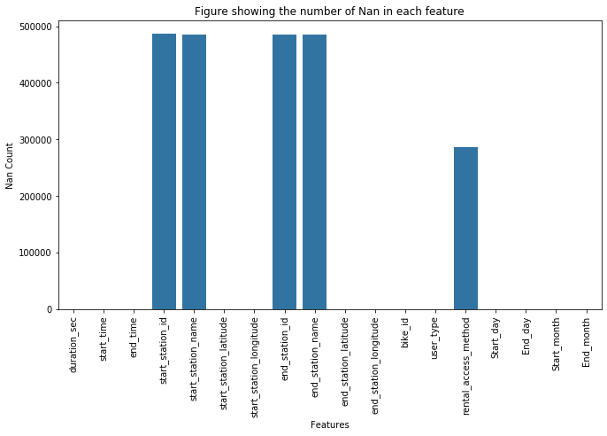

```python
na_counts = df_merged.isna().sum()
plt.figure(figsize = (11,6))
base_color = sns.color_palette()[0]
sns.barplot(na_counts.index.values, na_counts, color = base_color)
plt.xlabel('Features')
plt.ylabel('Nan Count')
plt.title('Figure showing the number of Nan in each feature')
plt.xticks(rotation = 90);
```

```python
# shape of merged data frame
print('The shape of the merged data set is {}'.format(df_merged.shape))
```

```
The shape of the merged data set is (905007, 18)
```

## The main feature(s) of interest in the dataset

> - User Type
> - Rental Access Method

## Features in the dataset that will help support investigation of the main features

> - duration_sec
> - start_day
> - end_day
> - Start_month
> - End_month
> - start_station_latitude
> - start_station_longitude
> - end_station_latitude
> - end_station_longitude

## Univariate Exploration

> In this section, we will be investigating distributions of individual variables. To find unusual points or outliers, and take a deeper look into each variable to clean things up and prepare to look at relationships between variables.

## Univariate Exploration of the Main Features

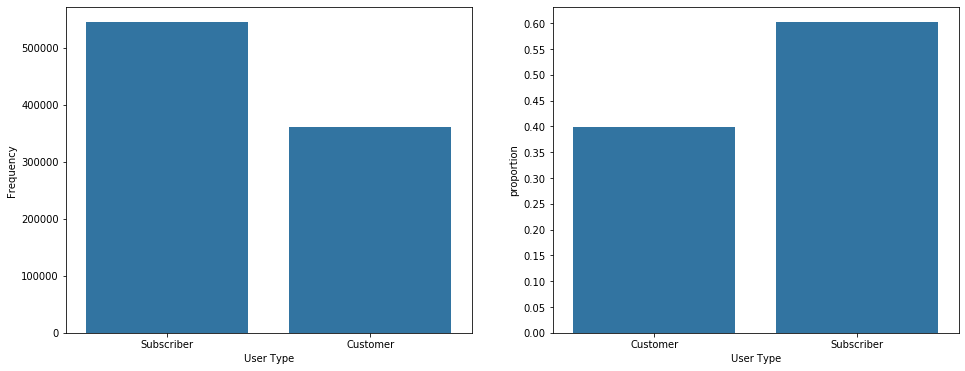

```python
# Univariate exploration of User type feature using bar chart
plt.figure(figsize = (16, 6))
plt.subplot(1,2,1)
base_color = sns.color_palette()[0]
user_type_order = df_merged['user_type'].value_counts().index
sns.countplot(data = df_merged, x = 'user_type', color = base_color, order = user_type_order)
plt.xlabel('User Type')
plt.ylabel('Frequency')
plt.xticks(rotation = 0)

# get proportion taken by most common group for derivation
# of tick marks
n_points = df_merged.shape[0]
max_count = df_merged['user_type'].value_counts().max()
max_prop = max_count / n_points

# generate tick mark locations and names
tick_props = np.arange(0, max_prop, 0.05)
tick_names = ['{:0.2f}'.format(v) for v in tick_props]

# create the plot
plt.subplot(1,2,2)
base_color = sns.color_palette()[0]
sns.countplot(data =df_merged , x = 'user_type', color = base_color)
plt.yticks(tick_props * n_points, tick_names)
plt.ylabel('proportion')
plt.xlabel('User Type')
plt.xticks(rotation = 0);
```

## Comment

> The bar chart above show the ditribution of the user type feature in term of frequency and proportion. From the chart above, we can observe that we have we have more user type of category Subcriber than user type of category customer.

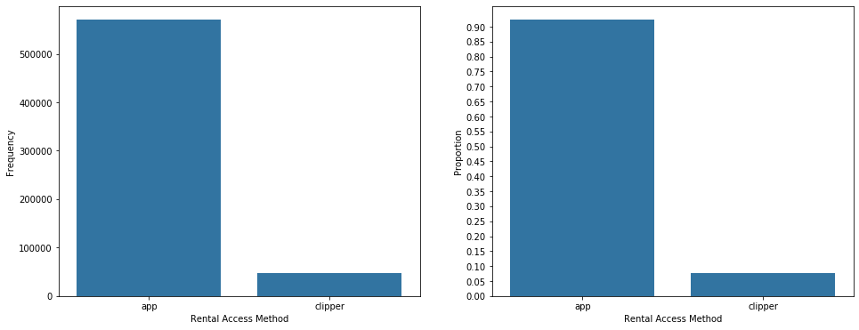

```python
# Univariate exploration of the rental_access_method feature using bar chart
plt.figure(figsize = (16, 6))
plt.subplot(1,2,1)
base_color = sns.color_palette()[0]
user_type_order = df_merged['rental_access_method'].value_counts().index
sns.countplot(data = df_merged, x = 'rental_access_method', color = base_color, order = user_type_order)
plt.xlabel('Rental Access Method')
plt.ylabel('Frequency')
plt.xticks(rotation = 0)

# get proportion taken by most common group for derivation
# of tick marks
n_points = df_merged['rental_access_method'].value_counts().sum()
max_count = df_merged['rental_access_method'].value_counts().max()
max_prop = max_count / n_points

# generate tick mark locations and names
tick_props = np.arange(0, max_prop, 0.05)
tick_names = ['{:0.2f}'.format(v) for v in tick_props]

# create the plot
plt.subplot(1,2,2)
base_color = sns.color_palette()[0]
sns.countplot(data =df_merged , x = 'rental_access_method', color = base_color)
plt.yticks(tick_props * n_points, tick_names)
plt.ylabel('Proportion')
plt.xlabel('Rental Access Method')
plt.xticks(rotation = 0);
```

## Comment

> The bar chart above show the ditribution of the rental access method feature in term of frequency and proportion. From the chart above, we can observe that we have we have more rental access method of app than rental access mwthod of category clipper.

## Univariate Exploration of the Support Features

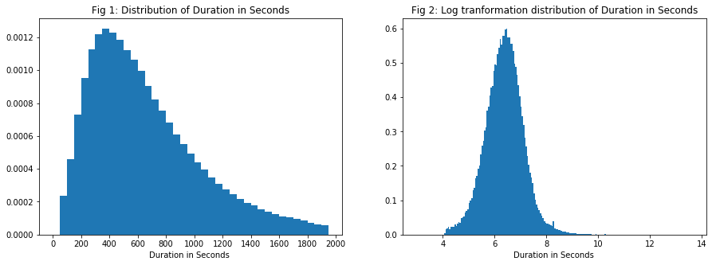

```python
# Univariate visualization of Duration in second
plt.figure(figsize = [15, 5])
plt.subplot(1, 2, 1)
bin_edges = np.arange(0, 2000, 50)
plt.hist(data = df_merged, x = 'duration_sec', bins =bin_edges, density = True)
plt.xticks([0, 200, 400, 600, 800, 1000, 1200, 1400, 1600, 1800, 2000])
plt.title('Fig 1: Distribution of Duration in Seconds')
plt.xlabel('Duration in Seconds ');

# Univariate visualization of Log transformation of duration in seconds
plt.subplot(1, 2, 2)
# Univariate visualization of Duration in second
duration_log = np.log(df_merged['duration_sec'])
bin_edges = np.arange(3, duration_log.max()+0.05, 0.05)
plt.hist(duration_log, bins =bin_edges, density = True)
plt.title('Fig 2: Log tranformation distribution of Duration in Seconds')
plt.xlabel('Duration in Seconds ');
```

## Comment

> The above, show the histogram ditribution of the duration in seconds variable in the data set. Outliers where detected in the data and Log transformation was used to transform the data to a range between 3 and 14. Fig 1 above shows that the distribution is right skewed. The log transformation histogram shows that the distrubution is normally distributed.

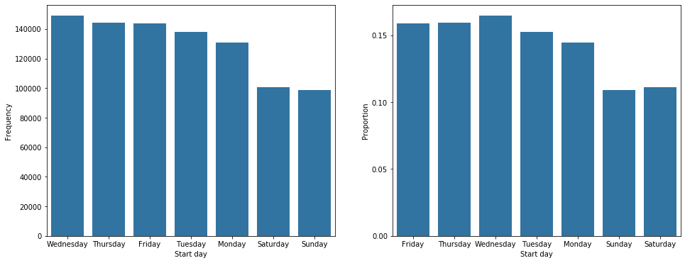

```python
# Univariate exploration of the Start day feature using bar chart
plt.figure(figsize = (16, 6))
plt.subplot(1,2,1)
base_color = sns.color_palette()[0]
user_type_order = df_merged['Start_day'].value_counts().index
sns.countplot(data = df_merged, x = 'Start_day', color = base_color, order = user_type_order)
plt.xlabel('Start day')
plt.ylabel('Frequency')
plt.xticks(rotation = 0)

# get proportion taken by most common group for derivation
# of tick marks
n_points = df_merged['Start_day'].value_counts().sum()
max_count = df_merged['Start_day'].value_counts().max()
max_prop = max_count / n_points

# generate tick mark locations and names
tick_props = np.arange(0, max_prop, 0.05)
tick_names = ['{:0.2f}'.format(v) for v in tick_props]

# create the plot
plt.subplot(1,2,2)
base_color = sns.color_palette()[0]
sns.countplot(data =df_merged , x = 'Start_day', color = base_color)
plt.yticks(tick_props * n_points, tick_names)
plt.ylabel('Proportion')
plt.xlabel('Start day')
plt.xticks(rotation = 0);
```

## Comment

> The chart above shows the ditribution of the prefered start day for riders. the chart above shows that the preferred start day is wednesday followed closely by thursday and then friday. The chart also shows that the least prefered day for riders are saturday and sunday.

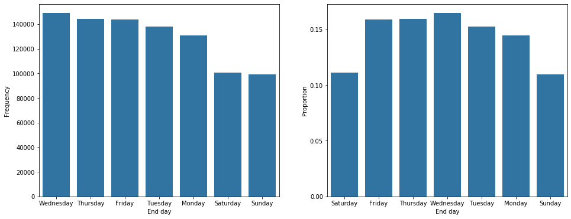

```python
# Univariate exploration of the End day feature using bar chart
plt.figure(figsize = (16, 6))
plt.subplot(1,2,1)
base_color = sns.color_palette()[0]
user_type_order = df_merged['End_day'].value_counts().index
sns.countplot(data = df_merged, x = 'End_day', color = base_color, order = user_type_order)
plt.xlabel('End day')
plt.ylabel('Frequency')
plt.xticks(rotation = 0)

# get proportion taken by most common group for derivation
# of tick marks
n_points = df_merged['End_day'].value_counts().sum()
max_count = df_merged['End_day'].value_counts().max()
max_prop = max_count / n_points

# generate tick mark locations and names
tick_props = np.arange(0, max_prop, 0.05)
tick_names = ['{:0.2f}'.format(v) for v in tick_props]

# create the plot
plt.subplot(1,2,2)
base_color = sns.color_palette()[0]
sns.countplot(data =df_merged , x = 'End_day', color = base_color)
plt.yticks(tick_props * n_points, tick_names)
plt.ylabel('Proportion')
plt.xlabel('End day')
plt.xticks(rotation = 0);
```

## Comment

> The chart above shows the ditribution of the prefered end day for riders. the chart above shows that the preferred start day is wednesday followed closely by thursday and then friday. The chart also shows that the least prefered day for riders are saturday and sunday.

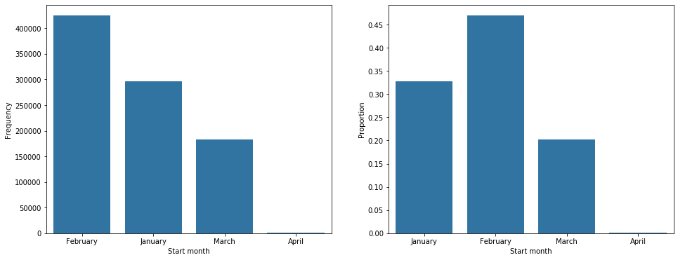

```python
# Univariate exploration of the Start month feature using bar chart
plt.figure(figsize = (16, 6))
plt.subplot(1,2,1)
base_color = sns.color_palette()[0]
user_type_order = df_merged['Start_month'].value_counts().index
sns.countplot(data = df_merged, x = 'Start_month', color = base_color, order = user_type_order)
plt.xlabel('Start month')
plt.ylabel('Frequency')
plt.xticks(rotation = 0)

# get proportion taken by most common group for derivation
# of tick marks
n_points = df_merged['Start_month'].value_counts().sum()
max_count = df_merged['Start_month'].value_counts().max()
max_prop = max_count / n_points

# generate tick mark locations and names
tick_props = np.arange(0, max_prop, 0.05)
tick_names = ['{:0.2f}'.format(v) for v in tick_props]

# create the plot
plt.subplot(1,2,2)
base_color = sns.color_palette()[0]
sns.countplot(data =df_merged , x = 'Start_month', color = base_color)
plt.yticks(tick_props * n_points, tick_names)
plt.ylabel('Proportion')
plt.xlabel('Start month')
plt.xticks(rotation = 0);
```

## Comment

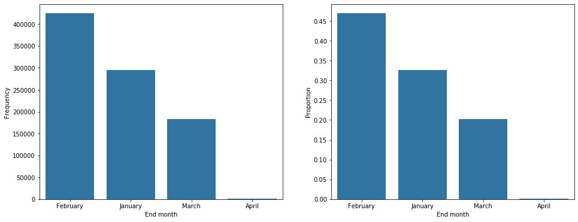

```python
# Univariate exploration of the Start month feature using bar chart
plt.figure(figsize = (16, 6))
plt.subplot(1,2,1)
base_color = sns.color_palette()[0]
user_type_order = df_merged['End_month'].value_counts().index
sns.countplot(data = df_merged, x = 'End_month', color = base_color, order = user_type_order)
plt.xlabel('End month')
plt.ylabel('Frequency')
plt.xticks(rotation = 0)

# get proportion taken by most common group for derivation
# of tick marks
n_points = df_merged['End_month'].value_counts().sum()
max_count = df_merged['End_month'].value_counts().max()
max_prop = max_count / n_points

# generate tick mark locations and names
tick_props = np.arange(0, max_prop, 0.05)
tick_names = ['{:0.2f}'.format(v) for v in tick_props]

# create the plot
plt.subplot(1,2,2)
base_color = sns.color_palette()[0]
sns.countplot(data =df_merged , x = 'End_month', color = base_color)
plt.yticks(tick_props * n_points, tick_names)
plt.ylabel('Proportion')
plt.xlabel('End month')
plt.xticks(rotation = 0);
```

## Comment

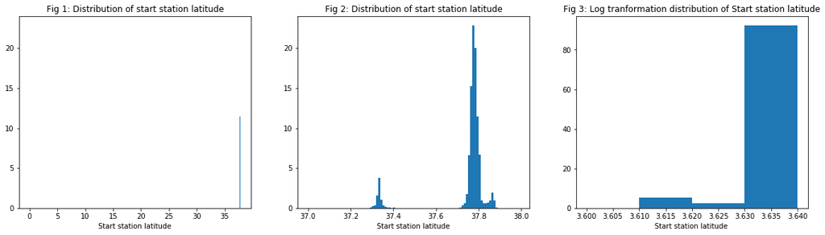

```python
# Univariate visualization of start station latitude
plt.figure(figsize = [20, 5])

plt.subplot(1,3,1)
bin_edges = np.arange(0,df_merged['start_station_latitude'].max()+0.01 , 0.01 )
plt.hist(data = df_merged, x = 'start_station_latitude', bins =bin_edges, density = True)
plt.title('Fig 1: Distribution of start station latitude')
plt.xlabel('Start station latitude');

plt.subplot(1, 3, 2)
bin_edges = np.arange(37, 38, 0.01 )
plt.hist(data = df_merged, x = 'start_station_latitude', bins =bin_edges, density = True)
#plt.xticks([0, 200, 400, 600, 800, 1000, 1200, 1400, 1600, 1800, 2000])
plt.title('Fig 2: Distribution of start station latitude')
plt.xlabel('Start station latitude');

plt.subplot(1, 3, 3)
duration_log = np.log(df_merged['start_station_latitude'])
bin_edges = np.arange(3.6, duration_log.max()+0.01, 0.01)
plt.hist(duration_log, bins =bin_edges, density = True)
plt.title('Fig 3: Log tranformation distribution of Start station latitude')
plt.xlabel('Start station latitude ');
```

## Comment

> The chart above show the distribution of the start station latitude. There were outliers detected in the dats set as seen in the chart above. Hence the log transformation techniques was applied to the data set. Fig 3 above shows the chart of the log transformed data set while fig 2 above shows a sliced portion of the data set where majority of the points lie.

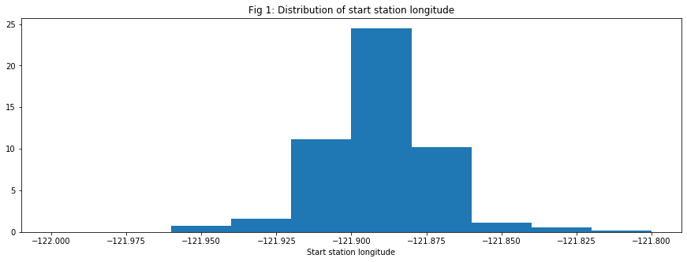

```python
# Univariate visualization of start station latitude
plt.figure(figsize = [15, 5])
bins2 = np.array([-122.00, -121.99, -121.96, -121.94, -121.92, -121.90, -121.88, -121.86, -121.84, -121.82, -121.80 ])
plt.hist(data = df_merged, x = 'start_station_longitude', density = True, bins = bins2)
plt.title('Fig 1: Distribution of start station longitude')
plt.xlabel('Start station longitude');
```

## Comment

> The chart above shows the distribution of the start station longitude. Outliers where detected in the data set hence the chat below showed a sliced portion of the data set where majority of the data points lie. The distribution above have the form of a noemal distribution.

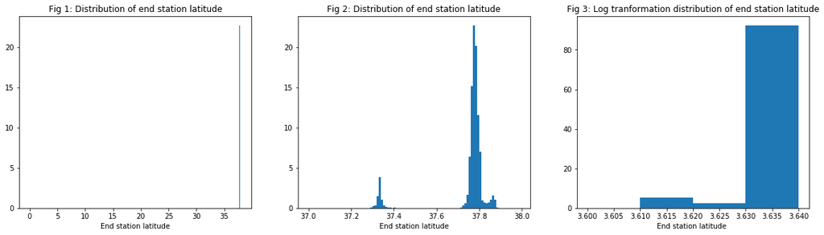

```python
# Univariate visualization of end station latitude
plt.figure(figsize = [20, 5])

plt.subplot(1,3,1)
bin_edges = np.arange(0,df_merged['end_station_latitude'].max()+0.01 , 0.01 )
plt.hist(data = df_merged, x = 'end_station_latitude', bins =bin_edges, density = True)
plt.title('Fig 1: Distribution of end station latitude')
plt.xlabel('End station latitude');

plt.subplot(1, 3, 2)
bin_edges = np.arange(37, 38, 0.01 )
plt.hist(data = df_merged, x = 'end_station_latitude', bins =bin_edges, density = True)
#plt.xticks([0, 200, 400, 600, 800, 1000, 1200, 1400, 1600, 1800, 2000])
plt.title('Fig 2: Distribution of end station latitude')
plt.xlabel('End station latitude');

plt.subplot(1, 3, 3)
duration_log = np.log(df_merged['end_station_latitude'])
bin_edges = np.arange(3.6, duration_log.max()+0.01, 0.01)
plt.hist(duration_log, bins =bin_edges, density = True)
plt.title('Fig 3: Log tranformation distribution of end station latitude')
plt.xlabel('End station latitude ');
```

## Comment

> The chart above show the distribution of the end station latitude. There were outliers detected in the dats set as seen in the chart above. Hence the log transformation techniques was applied to the data set. Fig 3 above shows the chart of the log transformed data set while fig 2 above shows a sliced portion of the data set where majority of the points lie.

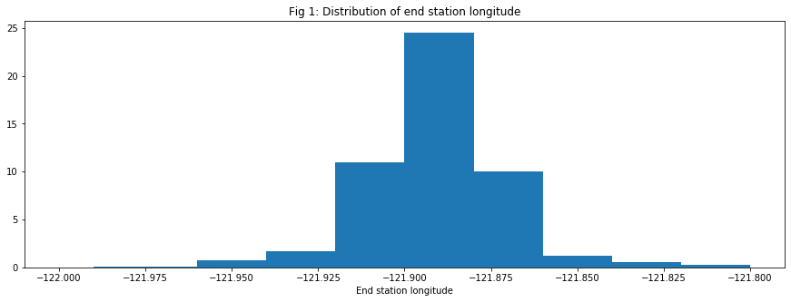

```python
# Univariate visualization of end station latitude
plt.figure(figsize = [15, 5])
bins2 = np.array([-122.00, -121.99, -121.96, -121.94, -121.92, -121.90, -121.88, -121.86, -121.84, -121.82, -121.80 ])
plt.hist(data = df_merged, x = 'end_station_longitude', density = True, bins = bins2)
plt.title('Fig 1: Distribution of end station longitude')
plt.xlabel('End station longitude');
```

## Comment

> The chart above shows the distribution of the end station longitude. Outliers where detected in the data set hence the chat below showed a sliced portion of the data set where majority of the data points lie. The distribution above have the form of a normal distribution.

## Bivariate Exploration

> In this section, we will investigate relationships between pairs of variables in your data. The pairs variables we shall be invetigating are variables listed out above as the main and support features.

```python
df_merged.columns
```

```
Index(['duration_sec', 'start_time', 'end_time', 'start_station_id',
       'start_station_name', 'start_station_latitude',
       'start_station_longitude', 'end_station_id', 'end_station_name',
       'end_station_latitude', 'end_station_longitude', 'bike_id', 'user_type',
       'rental_access_method', 'Start_day', 'End_day', 'Start_month',
       'End_month'],
      dtype='object')
```

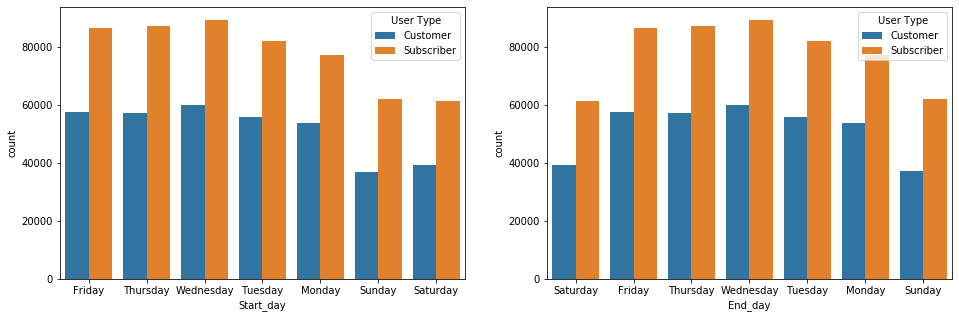

```python
# Bivaraite distribution of start day verse user type
plt.figure(figsize =(16, 5))

plt.subplot(1, 2, 1)
sns.countplot(data = df_merged, x = 'Start_day', hue = 'user_type')
plt.legend(title = 'User Type');

# Bivaraite distribution of end day verse user type
plt.subplot(1, 2,2)
sns.countplot(data = df_merged, x = 'End_day', hue = 'user_type')
plt.legend(title = 'User Type');
```

## Comment

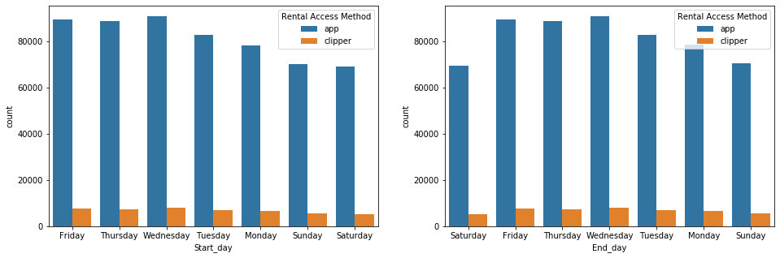

```python
# Bivaraite distribution of start day verse rental access method
plt.figure(figsize =(16, 5))

plt.subplot(1, 2, 1)
sns.countplot(data = df_merged, x = 'Start_day', hue = 'rental_access_method')
plt.legend(title = 'Rental Access Method');

# Bivaraite distribution of end day verse rental access method
plt.subplot(1, 2,2)
sns.countplot(data = df_merged, x = 'End_day', hue = 'rental_access_method')
plt.legend(title = 'Rental Access Method');
```

## Comment

> The chart above shows the ditribution of start day and end day by rental access method. From the chart above, we could see that the rental access method of category **app** has majority of the riders for both start day and end day. From the chart above, majority of the riders of rental access method app start day and end day where on wednesday, thursday and friday while the least start day and end day where on saturday and sunday. Same holds true for rental access method clipper.

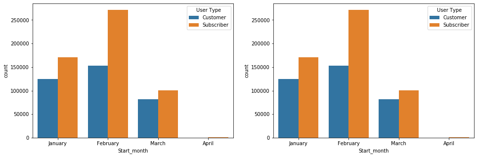

```python
plt.figure(figsize =(16, 5))

# Bivaraite distribution of start month verse user type
plt.subplot(1, 2, 1)
sns.countplot(data = df_merged, x = 'Start_month', hue = 'user_type')
plt.legend(title = 'User Type');

# Bivaraite distribution of end month verse user type
plt.subplot(1, 2,2)
sns.countplot(data = df_merged, x = 'Start_month', hue = 'user_type')
plt.legend(title = 'User Type');
```

## Comment

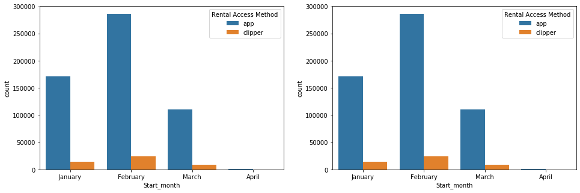

```python
plt.figure(figsize =(16, 5))

# Bivaraite distribution of start month verse rental access method
plt.subplot(1, 2, 1)
sns.countplot(data = df_merged, x = 'Start_month', hue = 'rental_access_method')
plt.legend(title = 'Rental Access Method');

# Bivaraite distribution of end month verse rental access method
plt.subplot(1, 2,2)
sns.countplot(data = df_merged, x = 'Start_month', hue = 'rental_access_method')
plt.legend(title = 'Rental Access Method');
```

## Comment

```python
df_merged.head()
```

|  | duration_sec | start_time | end_time | start_station_id | start_station_name | start_station_latitude | start_station_longitude | end_station_id | end_station_name | end_station_latitude | end_station_longitude | bike_id | user_type | rental_access_method | Start_day | End_day | Start_month | End_month |
| --- | --- | --- | --- | --- | --- | --- | --- | --- | --- | --- | --- | --- | --- | --- | --- | --- | --- | --- |
| 0 | 83118 | 2020-01-31 | 2020-02-01 | 400.0 | Buchanan St at North Point St | 37.804272 | -122.433537 | 400.0 | Buchanan St at North Point St | 37.804272 | -122.433537 | 13052 | Customer | NaN | Friday | Saturday | January | February |
| 1 | 68239 | 2020-01-31 | 2020-02-01 | 99.0 | Folsom St at 15th St | 37.767037 | -122.415443 | 99.0 | Folsom St at 15th St | 37.767037 | -122.415443 | 12235 | Subscriber | NaN | Friday | Saturday | January | February |
| 2 | 55407 | 2020-01-31 | 2020-02-01 | 197.0 | El Embarcadero at Grand Ave | 37.808848 | -122.249680 | 197.0 | El Embarcadero at Grand Ave | 37.808848 | -122.249680 | 12822 | Customer | NaN | Friday | Saturday | January | February |
| 3 | 54929 | 2020-01-31 | 2020-02-01 | 197.0 | El Embarcadero at Grand Ave | 37.808848 | -122.249680 | 197.0 | El Embarcadero at Grand Ave | 37.808848 | -122.249680 | 11705 | Customer | NaN | Friday | Saturday | January | February |
| 4 | 55700 | 2020-01-31 | 2020-02-01 | 12.0 | Pier 1/2 at The Embarcadero | 37.796389 | -122.394586 | 371.0 | Lombard St at Columbus Ave | 37.802746 | -122.413579 | 3673 | Customer | NaN | Friday | Saturday | January | February |

```python
# Log transformation of the duratio in second feature
df_merged['duration_sec'] = np.log10(df_merged['duration_sec'])
```

```python
df_merged.head()
```

|  | duration_sec | start_time | end_time | start_station_id | start_station_name | start_station_latitude | start_station_longitude | end_station_id | end_station_name | end_station_latitude | end_station_longitude | bike_id | user_type | rental_access_method | Start_day | End_day | Start_month | End_month |
| --- | --- | --- | --- | --- | --- | --- | --- | --- | --- | --- | --- | --- | --- | --- | --- | --- | --- | --- |
| 0 | 4.919695 | 2020-01-31 | 2020-02-01 | 400.0 | Buchanan St at North Point St | 37.804272 | -122.433537 | 400.0 | Buchanan St at North Point St | 37.804272 | -122.433537 | 13052 | Customer | NaN | Friday | Saturday | January | February |
| 1 | 4.834033 | 2020-01-31 | 2020-02-01 | 99.0 | Folsom St at 15th St | 37.767037 | -122.415443 | 99.0 | Folsom St at 15th St | 37.767037 | -122.415443 | 12235 | Subscriber | NaN | Friday | Saturday | January | February |
| 2 | 4.743565 | 2020-01-31 | 2020-02-01 | 197.0 | El Embarcadero at Grand Ave | 37.808848 | -122.249680 | 197.0 | El Embarcadero at Grand Ave | 37.808848 | -122.249680 | 12822 | Customer | NaN | Friday | Saturday | January | February |
| 3 | 4.739802 | 2020-01-31 | 2020-02-01 | 197.0 | El Embarcadero at Grand Ave | 37.808848 | -122.249680 | 197.0 | El Embarcadero at Grand Ave | 37.808848 | -122.249680 | 11705 | Customer | NaN | Friday | Saturday | January | February |
| 4 | 4.745855 | 2020-01-31 | 2020-02-01 | 12.0 | Pier 1/2 at The Embarcadero | 37.796389 | -122.394586 | 371.0 | Lombard St at Columbus Ave | 37.802746 | -122.413579 | 3673 | Customer | NaN | Friday | Saturday | January | February |

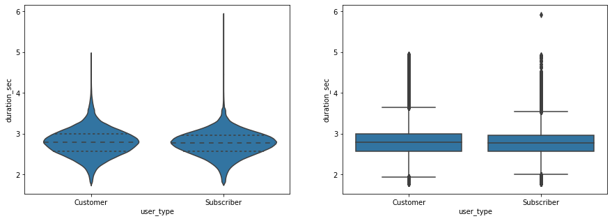

```python
# box plot and violin plot of the duration in seconds by user type
plt.figure(figsize = [15, 5])
base_color = sns.color_palette()[0]

# left plot: violin plot
plt.subplot(1, 2, 1)
ax1 = sns.violinplot(data = df_merged, x = 'user_type', y = 'duration_sec', color = base_color, inner = 'quartile')

# right plot: box plot
plt.subplot(1, 2, 2)
sns.boxplot(data = df_merged, x = 'user_type', y = 'duration_sec', color = base_color)
plt.ylim(ax1.get_ylim()); # set y-axis limits to be same as left plot
```

## Comment

> The chart above is a box plot and violin plot showing the distribution of user type by duration in seconds. The chart shows that both category of the user type ( Customer and Subscribers) has same median, and quartiles and there is a presence of outliers.

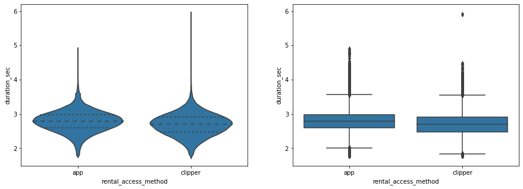

```python
# box plot and violin plot of the duration in seconds by rental_access_method
plt.figure(figsize = [15, 5])
base_color = sns.color_palette()[0]

# left plot: violin plot
plt.subplot(1, 2, 1)
ax1 = sns.violinplot(data = df_merged, x = 'rental_access_method', y = 'duration_sec', color = base_color, inner = 'quartile')

# right plot: box plot
plt.subplot(1, 2, 2)
sns.boxplot(data = df_merged, x = 'rental_access_method', y = 'duration_sec', color = base_color)
plt.ylim(ax1.get_ylim()); # set y-axis limits to be same as left plot
```

## Comment

> The chart above is a box plot and violin plot showing the distribution of rentall access method by duration in seconds. The chart shows that both category of the rental access method ( app and clipper) do not have same median, and quartiles but there is a presence of outliers as seen in the chart above.

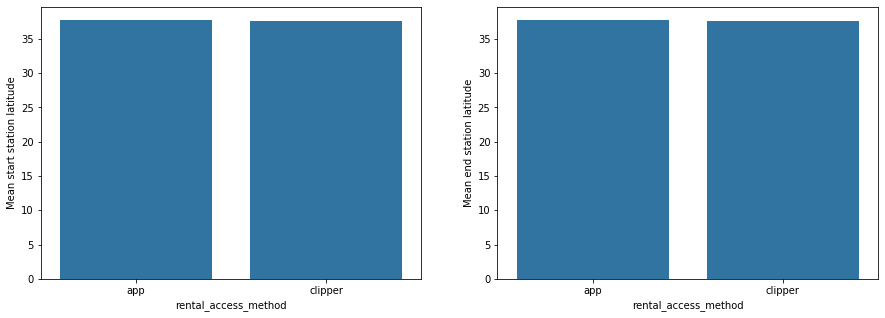

```python
# Bar plot for rental_access_method by start_station_latitude
plt.figure(figsize = [15, 5])
plt.subplot(1, 2, 1)
base_color = sns.color_palette()[0]
sns.barplot(data = df_merged, x = 'rental_access_method', y = 'start_station_latitude', color = base_color, errcolor=".2" )
plt.ylabel('Mean start station latitude')

#Bar plot of rental_access_method by end station latitude
plt.subplot(1, 2, 2)
base_color = sns.color_palette()[0]
sns.barplot(data = df_merged, x = 'rental_access_method', y = 'end_station_latitude', color = base_color )
plt.ylabel('Mean end station latitude');
```

## Comment

> The bar plot above shows the distribution of rental access method by start station latitude and end station latitude. The distribution of rental access method for both statrt station latitude and end station latitude are the same with mean of approximately 38.

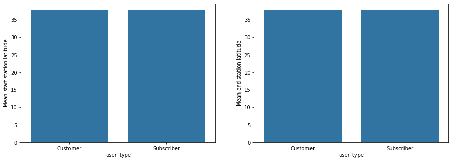

```python
# Bar plot for user_type by start_station_latitude
plt.figure(figsize = [15, 5])
plt.subplot(1, 2, 1)
base_color = sns.color_palette()[0]
sns.barplot(data = df_merged, x = 'user_type', y = 'start_station_latitude', color = base_color, errcolor=".2" )
plt.ylabel('Mean start station latitude');

#Bar plot of user_type by end station latitude
plt.subplot(1, 2, 2)
base_color = sns.color_palette()[0]
sns.barplot(data = df_merged, x = 'user_type', y = 'end_station_latitude', color = base_color, errcolor=".2" )
plt.ylabel('Mean end station latitude');
```

## Comment

> The bar plot above shows the distribution of user type by start station latitude and end station latitude. The distribution of user for both statrt station latitude and end station latitude are the same with mean of approximately 38.

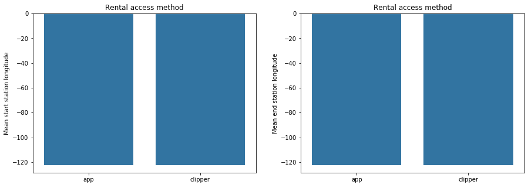

```python
# Bar plot for rental_access_method by start_station_longitude
plt.figure(figsize = [15, 5])
plt.subplot(1, 2, 1)
base_color = sns.color_palette()[0]
sns.barplot(data = df_merged, x = 'rental_access_method', y = 'start_station_longitude', color = base_color )
plt.ylabel('Mean start station longitude')
plt.xlabel(' ')
plt.title('Rental access method')

#Bar plot of rental_access_method by end station longitude
plt.subplot(1, 2, 2)
base_color = sns.color_palette()[0]
sns.barplot(data = df_merged, x = 'rental_access_method', y = 'end_station_longitude', color = base_color )
plt.ylabel('Mean end station longitude')
plt.xlabel(' ')
plt.title('Rental access method');
```

## Comment

> The above chart shows the distribution of rental access method by start station longitude and end station longitude. both charts then to have same distribution.

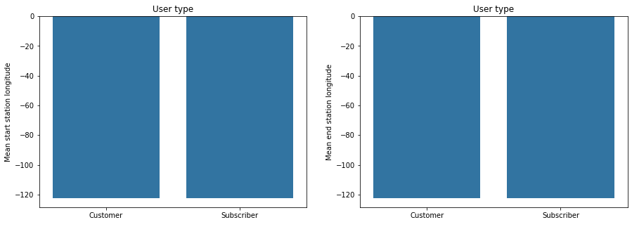

```python
# Bar plot for user_type by start_station_longitude
plt.figure(figsize = [15, 5])
plt.subplot(1, 2, 1)
base_color = sns.color_palette()[0]
sns.barplot(data = df_merged, x = 'user_type', y = 'start_station_longitude', color = base_color, errcolor=".2" )
plt.xlabel(' ')
plt.ylabel('Mean start station longitude')
plt.title('User type')

#Bar plot of user_type by end station longitude
plt.subplot(1, 2, 2)
base_color = sns.color_palette()[0]
sns.barplot(data = df_merged, x = 'user_type', y = 'end_station_longitude', color = base_color )
plt.ylabel('Mean end station longitude')
plt.xlabel(' ')
plt.title('User type');
```

## Comment

> The above chart shows the distribution of user type by start station longitude and end station longitude. both charts then to have same distribution.

## Multivariate Visualization

> In this section we shall be creating plots of three or more variable to investigate our data even further. Our investigations will be justified, and follo from the previous section.

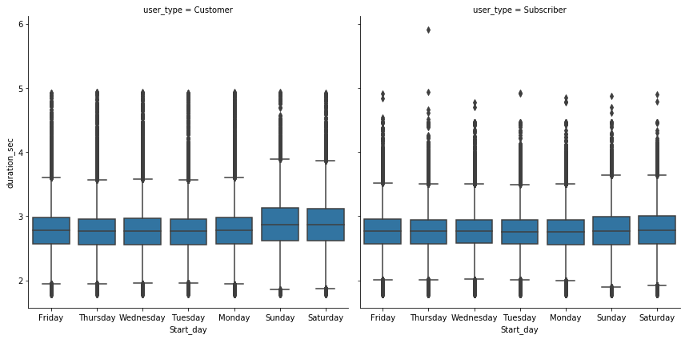

```python
# Multivariate box plot of start day and duration in second hued by user type
import warnings
warnings.filterwarnings('ignore')
warnings.simplefilter('ignore')
plt.figure(figsize = [15, 5])
g = sns.FacetGrid(data = df_merged, col = 'user_type', size = 6)
g.map(sns.boxplot, 'Start_day', 'duration_sec');
```

## Comment

> The chart above shows a box distribution of start day with duration in seconds hue by user type. Under the user type category **Customer** sunday and saturday has a higher median and quartiles. For the category **Subscriber** all the days has the same median and quartiles except for saturday and sunday with a slight difference.

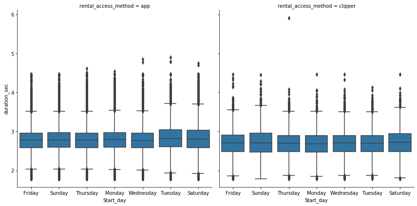

```python
# Multivariate box plot of start day and duration in second hued by rental access method
import warnings
warnings.filterwarnings('ignore')
warnings.simplefilter('ignore')
plt.figure(figsize = [15, 5])
g = sns.FacetGrid(data = df_merged, col = 'rental_access_method', size = 6)
g.map(sns.boxplot, 'Start_day', 'duration_sec');
```

## Comment

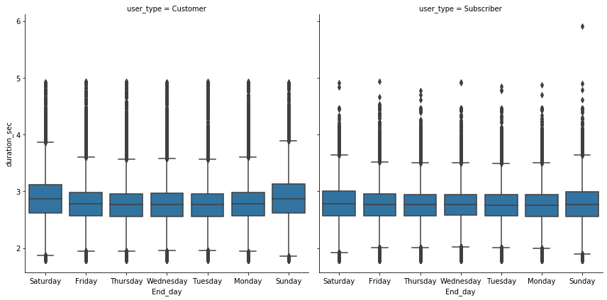

```python
# Multivariate box plot of end day and duration in second hued by user type
import warnings
warnings.filterwarnings('ignore')
warnings.simplefilter('ignore')
plt.figure(figsize = [15, 5])
g = sns.FacetGrid(data = df_merged, col = 'user_type', size = 6)
g.map(sns.boxplot, 'End_day', 'duration_sec');
```

## Comment

> The chart above shows a box distribution of end day with duration in seconds hue by user type. Under the user type category **Customer** sunday and saturday has a higher median and quartiles. For the category **Subscriber** all the days has the same median and quartiles except for saturday and sunday with a slight difference.

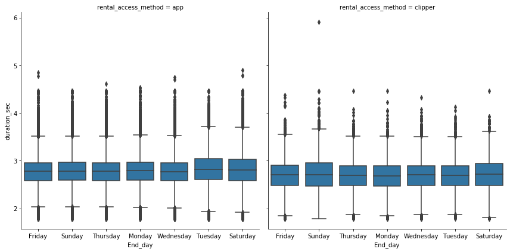

```python
# Multivariate box plot of end day and duration in second hued by rental_access_method
import warnings
warnings.filterwarnings('ignore')
warnings.simplefilter('ignore')
plt.figure(figsize = [15, 5])
g = sns.FacetGrid(data = df_merged, col = 'rental_access_method', size = 6)
g.map(sns.boxplot, 'End_day', 'duration_sec');
```

## Comment

> The chart above shows a box distribution of end day with duration in seconds hue by rental access method. Under the rental access method category **app** tuesday and saturday has a higher median and quartiles. For the category **clipper** all the days has the same median and quartiles except for saturday and sunday with a slight difference.

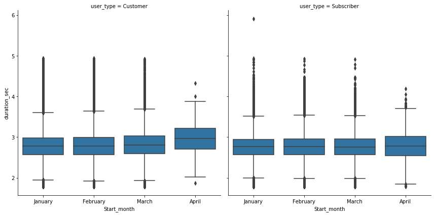

```python
# Multivariate box plot of start month and duration in second hued by user type
import warnings
warnings.filterwarnings('ignore')
warnings.simplefilter('ignore')
plt.figure(figsize = [15, 5])
g = sns.FacetGrid(data = df_merged, col = 'user_type', size = 6)
g.map(sns.boxplot, 'Start_month', 'duration_sec');
```

## Comment

> The chart above shows a box distribution of start month with duration in seconds hue by user type. Under the user type category **Customer** april has a higher median and quartiles. For the category **Subscriber** all the months has the same median and quartiles except for april with a slight difference.

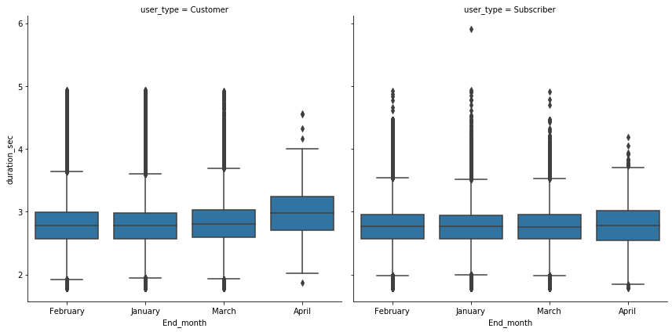

```python
# Multivariate box plot of end month and duration in second hued by user_type
import warnings
warnings.filterwarnings('ignore')
warnings.simplefilter('ignore')
plt.figure(figsize = [15, 5])
g = sns.FacetGrid(data = df_merged, col = 'user_type', size = 6)
g.map(sns.boxplot, 'End_month', 'duration_sec');
```

## Comment

> The chart above shows a box distribution of end month with duration in seconds hue by user type. Under the user type category **Customer** april has a higher median and quartiles. For the category **Subscriber** all the months has the same median and quartiles except for april with a slight difference.

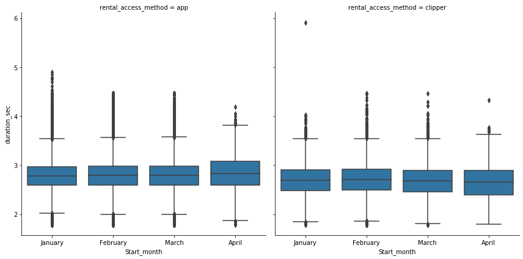

```python
# Multivariate box plot of start month and duration in second hued by rental_access_method
import warnings
warnings.filterwarnings('ignore')
warnings.simplefilter('ignore')
plt.figure(figsize = [15, 5])
g = sns.FacetGrid(data = df_merged, col = 'rental_access_method', size = 6)
g.map(sns.boxplot, 'Start_month', 'duration_sec');
```